# Quantifying the benefits of using decision models with response time and accuracy data

Tom Stafford

1  
t.stafford@sheffield.ac.uk

Angelo Pirrone

2

Mike Croucher

3

Anna Krystalli

4

Abstract

Across diverse subfields experimentalists collect response time and accuracy data. Inter-subject and inter-group speed-accuracy trade-offs (SATOs) are a well-known possibility which are often inadequately addressed. Many experiments focus on a single variable (e.g. psychophysics paradigms analysing accuracy alone), or involve a suboptimal analytic correction (e.g. dividing accuracy by response time). Models of decision making, such as the drift diffusion model (DDM), provide a principled account of the decision making process, allowing the recovery of SATO-unconfounded decision parameters from observed behavioural variables. For plausible parameters of a typical between-groups experiment we simulate experimental data, for both real and null group differences, and for both systematic and null SATOs, and fit the DDM. This exercise allows us to make a number of concrete recommendations for experimentalists: we show, in terms of reduction of required sample size, how decision modelling allows more efficient data collection for set statistical power; we confirm and depict the non-linear speed-accuracy relation; we show how much more sensitive accuracy is as a measure than response time.

```r
library(knitr)
knitr::opts_chunk$set(echo = FALSE, message=FALSE, warning=FALSE, fig.height=2, fig.width=4)
```

# Abbreviations

DDM - Drift diffusion model

SATO - Speed-accuracy trade-off

# Introduction

## Speed accuracy trade-offs

Speed and accuracy of responding are fundamental measures of performance, collected by behavioural scientists across diverse domains. The two measures are related by the speed-accuracy trade-off (SATO). For reviews of this topic see Wickelgren (1977); Heitz (2014).

The SATO is inextricably linked to the nature of decision making — it arises whenever we wish to respond as fast and as accurately possible based on uncertain incoming information. More accurate responses require more information, which takes longer to accumulate; faster responses forgoe collecting additional information at the cost of higher error rates. Importantly, because the SATO in unavoidable it is also necessary that all decision-making processes are positioned with respect to the trade-off. This does not need to be done deliberately or explicitly, but any decision process can be characterised as adopting some trade-off between speed and accuracy. For the tasks studied by psychologists, it is important to recognise that there will be individual differences, as well as task and group-related differences, in how participants position themselves on the SATO.

Outside of researched focussed on SATOs explicitly, different practices have been adopted to account for SATOs or potential SATOs in behavioural data. One approach is to ignore either speed or accuracy. For example, ignoring speed of response is common in psychophysics, whereas some domains of cognitive psychology where high-accuracy is assumed, focus only on response times (e.g. Stafford, Ingram, and Gurney 2011)[^1], sometimes after a cursory check of error-rate data, or the failure of standard null-hypothesis test to reveal signficiant differences in error-rates. Another approach is to combine speed and accuracy. For example, in the domain of visual search it is common to calculate `efficiency’ scores by dividing search time by search accuracy as a proportion (e.g. Yates and Stafford 2018). Despite being widespread, there is evidence that this practice is unlikely to add clarity to analysis (Bruyer and Brysbaert 2011). We also note that the researchers who initially formulated the efficiency score explictly counselled *against* using it in the case of SATOs (Townsend and Ashby 1983).

The efficiency score shares with other recent suggestions for accounting for SATOs (Davidson and Martin 2013; Seli et al. 2013) the property that it assumes a linear relation between response time and accuracy. While such approaches may be better than focussing on a single behavioural variable, the assumption of linearity is at odds with work which has explicitly characterised the SATO (Fitts 1966; Wickelgren 1977; Heitz 2014) and has shown distinct a distinctly curvilinear relation between response time and accuracy. As such, although linear correction methods may work for some portions of the SATO, they are likely to be misleading, or at least fail to add clarity, where accuracy and/or speed approaches upper or lower limits of those variables.

## Context

The unprincipled combination of speed and accurary measures becomes an urgent issue when considered in the context of widespread questions surrounding the reliability of the literature in psychology. Established results fail to replicate, or replicate with substantially reduced effect sizes (Open Science Collaboration 2015; Pashler and Wagenmakers 2012).

Low statistical power has been a persistent problem across many areas of psychology and cognitive neuroscience (Button et al. 2013; Szucs and Ioannidis 2017; Stanley, Carter, and Doucouliagos 2017; Maxwell 2004; Sedlmeier and Gigerenzer 1989; Lovakov and Agadullina 2017), including, but not limited to, research areas which are bound by costly methods or hard-to-reach populations (Geuter et al. 2018; Bezeau and Graves 2001; J. Cohen 1962). This, combined with factors such as analytic flexibility (Simmons, Nelson, and Simonsohn 2011; Silberzahn et al. 2017) — which can only be increased by a lack of recognition of any optimal analysis method — has led to a widespread lack of faith in many published results (Ioannidis 2005).

Statistical power is defined with respect to the variability and availability of data, as well as the analysis proposed. For a set experimental design, an obvious candidate for increasing stastical power is to increase sample size, but this is not always easy. Each additonal participant costs additonal time, money and resources. This is especially true in the case of expensive methods, such as fMRI, or special populations which may be hard to recruit. More sensitive measures also increase statistical power: lower measurement error will tend to reduce variability so that the same mean differences produce larger observed effect sizes.

A motivation for the present work is to demonstrate the practical utility, in terms of increased statistical power, of combining speed and accuracy information in a principled manner. Such an innovation has the appeal of making the most of data which is normally collected, even if not analysed, whilst not requiring more participants (which is costly), or more trials per participant (which also has costs in terms of particpant fatigue which may be especially high for some popualations, e.g. children).

## Decision modelling

Models of the decision making process provide the foundation for the principled combination of speed and accuracy data, and thus afford experimenters access to considerable statistical power gains.

Many models exist in which decision making is represented by the accumulation of sensory evidence over time. When the accumulated evidence surpasses some threshold (also called a boundary) then a decision is triggered. The accuracy of the decision depends on which accumator crosses which boudary, the speed is given by time this takes, and thus such models can be used to fit speed and accuracy data within the same framework.

A prominant instance of such accumulator models is the so called drift-diffusion model developed by Roger Ratcliff (DDM Ratcliff 1978; Ratcliff and Rouder 1998). After a long and successful perdiod of development and application on purely behavioural data, the DDM model was at the centre of an important theoretical confluence. Neurophysiologists found evidence for accumulation like processes in neurons critical to sensory decision making (P. L. Smith and Ratcliff 2004; Gold and Shadlen 2001), whilst theoreticians recognised that accumulator models could be related to statistical methods of uncertain information intregration (Bogacz et al. 2006; Gold and Shadlen 2002). Under certain parameterisations many different decision models, all in the family of accumulator models, can be shown to be equivalent to the DDM, and this in turn equivalent to a statistical method which is optimal for making the fastest decision with a given error rate (or the most accurate decision within a fixed time).

While debate continues around the exact specification of the decision model which best reflects human decision making, there is a consensus that the DDM captures many essential features of decision processesing (but see Pirrone, Stafford, and Marshall (2014); Teodorescu, Moran, and Usher (2016); Pirrone et al. (2018)). As you would expect, the DDM has also shown considerable success modelling decision data across many different domains (Ratcliff and McKoon 2008). In the sense that the DDM implements a statistically optimal algorithm for accumulation for uncertain information, we would expect our neural machinery to implement the same algorithm in the absence of other constraints (Pirrone, Stafford, and Marshall 2014). The basic mechanism of the DDM is illustrated in Figure @ref(fig:ddm).

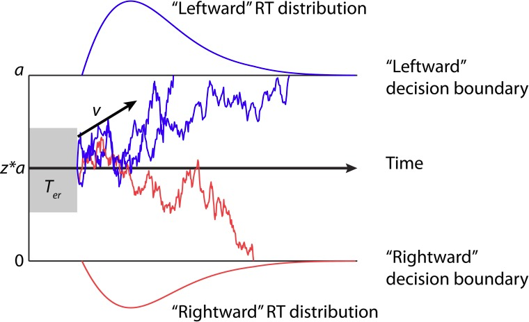

An illustration of the drift-diffusion model (DDM); taken from Zhang and Rowe, 2014. Here a decision between two choices, `leftward' and`rightward’ is shown. Parameters labelled are $v$, the drift rate which reflects the rate of evidence accumulation; $\alpha$, the boundary seperation, which reflect response conservativeness; $z$, the starting point, which biases the response based on pre-stimulus expectations and $T_{er}$, non-decision time, a fixed delay which does not vary with stimulus information.

For our purposes, the value of these decision models is that they provide a principled reconcilation of speed and accuracy data. Within this framework these observed behavioural measures reflect the hidden parameters of the decision model, most important of which (for our purposes) are the drift rate and boundary seperation, which reflect the strength of evidence accumulation (reflecting participant sensivitiy/stimulus salience) and the decision boundary (reflecting the conservativeness of the participant’s decision criterion; higher boundaries produce slower but more accurate responses).

By fitting the DDM we can deconfound the observed behavioural variables — speed and accuracy — and recover the putative generating parameters of the decision — drift and boundary seperation. In principle, this allows a more sensitive measure of participant capability (reflected in the drift parameter). Drift is a more sensitive measure because a) it is estimated using both speed *and* accuracy and b) it is isolated from the effect of different participant response thresholds (which are reflected in the boundary parameter).

Previous authors have established the in-principle gains of this approach. Within a psychophysics framework, Stone (2014) extended Palmer, Huk, and Shadlen (2005)’s decision model to show that response time and accuracy contain different, but possibly overlapping, components of Shannon information about the perceived stimulus. If these components do not overlap (as suggested by Stone, in preparation) then combining response time and accuracy data should provide better estimates of key parameters which govern the decision process than relying on either response time or accuracy alone. Previous authors have shown for specific paradigms and decisions that using decision models confers benefits beyond relying on speed, accuracy or some sub-optimal combination of the two, especially in the case of speed-accuracy trade-offs (e.g. Zhang and Rowe 2014; Park and Starns 2015). Our purpose here is not to make a theoretical innovation in decision modelling, but to use established decision models to demonstrate and quantify the benefits of decision modelling for experimentalists.

# Method

The broad approach is to consider a simple standard experimental design: a between groups comparison each group contains a number of participants who complete a number of decision trials, which provide both response time and accuracy data. We simulate data for true and null differences in drift (sensitivity) between the groups, as well as true and null differences in boundary (SATO) between the groups. By varying the number of simualated participants we generate a fixed number of `scenarios’ defined by true/null effects in sensitivty, true/null SATOs and experimental sample size. For each scenario we inspect the behavioural measures to see how senstive and specific they are to detecting true group differences. We also fit the DDM and estimate the participant drift parameters, similarly asking how sensitive and specific estimates of drift are to true group differences in drift. An overview of the method is provided in Figure @ref(fig:DDMprocess).

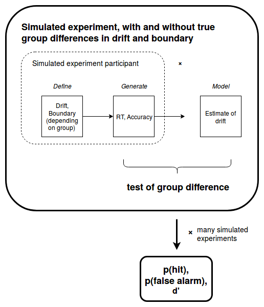

Overview of method

## Decision modelling

To generate simulated response data, and we use the Hieracrchical Drift Diffusion Model (HDDM, Wiecki, Sofer, and Frank 2013). This toolbox can also perform model fitting, which uses Bayesian estimation methods to similtaneously fit individual decision parameters and the group distributions from which they are drawn.

While the HDDM offers a principled and comprehensive model fitting approach, it is computationally expensive. An alternative model fitting method, the EZ-DDM (E.-J. Wagenmakers, Van Der Maas, and Grasman 2007) offers a simple approximation, fitting a decision model with a smaller number of parameters using an analytic method which is computationally cheap. Furthermore, the EZ-DDM has been shown to match the full DDM for a range of situations (Ravenzwaaij, Donkin, and Vandekerckhove 2017).

We use a particular framework for generating decision data and parameter fitting (the HDDM, Wiecki, Sofer, and Frank 2013) but we believe these results do not depend on the particular decision model deployed from the broad class of accumulator models. A provisional analysis using an alternative framework reveals quantatively similar results (results not shown here, but using the models of A. Voss and Voss (2007)). For some parameterisations several prominent decision models are equivalent (Bogacz et al. 2006). A recent collaborative analysis project found that desite a large diversity of fitting methods common inferences where across different decision models (Dutilh et al. 2016). A reasonable conclusion from this project was that in many circumstances the simple models should be preferred (Lerche and Voss 2016). Ratcliff and Childers (2015) claims that heirarchival bayesian methods of fitting, as we use here are best, at least for individual difference investigations (although see Jones and Dzhafarov (2014) who claim that many variants of the DDM cannot be successfully distinguished by empirial measurement).

Obviously, where we wish to simulate many thousands of independent experiments there are significant speed gains from parallelisation. Parallalisation was done by Mike Croucher, and the code run on University of Sheffield High Performance Computing cluser. A sense of the value of parallelisation can be had by noting the the data shown in, for example, Figure (fig:SATOdprime) would have taken around 1 calander month to generate on a single high performance machine, using the computationally `cheap’ EZ-DDM method. Python code for running the simulations, as well as the output data, figures and manuscript preparation files, is here https://github.com/tomstafford/ddm_sims.

## Analysis

Because we are not generating an analytic solution we cannot claim that our findings are true for all situations. Our aim is merely to show that for some reasonable choices of DDM parameters using decision modelling is a superior approach to analysing response time or accuracy alone or combining them in any suboptimal way.

To be able to make this claim of relevance of our simulations to typical psychology experiments we need to be able to justify that our parameter choice is plausible for a typical psychology experiment. In order to establish this we pick parameters which generate response times of the order of 1 second and accuracy of the order 90%.[^2]. Each participant contributes 40 decision (40 trials) to each experiment. Parameters for drift and boundary seperation are defined for the group and individual participant values for these parameters are drawn from the group parameters with some level of variability (and, in the case of true effects, a mean difference between the group values).

To illustrate this, we show in Figure @ref(fig:SATOdirect) a direct visualation of the speed-accuracy trade-off, by taking the base parameters we use in our simulated experiments and generating a single particpant’s average response time and accuracy, using 1000 different boundary seperation values. This shows the effect of varying boundary seperation alone, while all other decision parameters are stable.

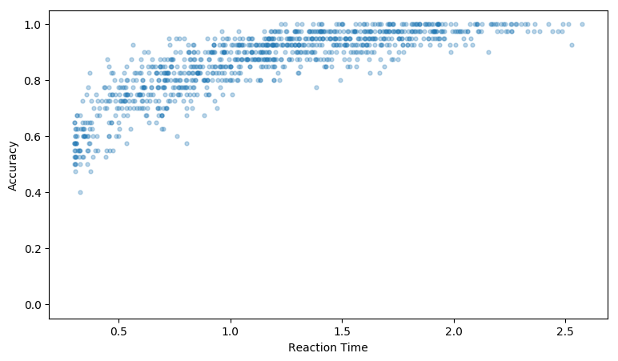

Directly visualising the speed-accuracy trade-off: average response time and accuracy from a single simulated particpant with all decision parameters kept fixed except for boundary seperation, which is drawn from a normal distibution (mean = 2, variance = 1) (1000 simulated experiments, each of 40 trials

For each scenario we simulate a large number of experiments, with participant parameters sampled each time from the defined distributions. For each experiment, any difference between groups is gauged with a standard two-sample t-test for the behavioural variables.

### Effect sizes

The drift and boundary paramters for each each simulated participant are drawn from declared group means, meaning that the true difference between groups can be expressed in terms of Cohen’s d effect size — the mean difference between the groups standardised by the within group variability.

For the observed variables, response time and accuracy, the effect sizes can only be observed, not declared, since these arise from the interaction of the DDM parameters and the DDM model which generates responses. The declared group difference in drift rate produces the observed effect size in response time and accuracy (which differ from each other), depending on both the level of noise in each simulated experiment, and the experiment design - specifically on the number of trials per participant.

Experiment designs which have a higher number of trials per participant effectively sample the true drift rate more accurately, and so have effect sizes for response time and accuracy which are closer to the ‘true’, declared, effect size in drift rate.

This issue sheds light on why decision modelling is more effective than analysing response time or accuracy alone (because it recovers the generating parameter, drift, which is more sensitive to group differences), and why there are differences in power between measuring response time and accuracy (because these variables show different observed effect sizes when generated by the same true different in drift rates). Figure @ref(fig:effectsizes) shows how declared differences in drift translate into observed effect sizes for response time and accuracy.

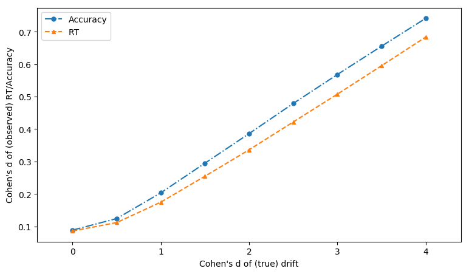

How differences in drift convert to observed differences in response time and accuracy (40 trials per ppt)

### Hits (power) and False Alarms (Alpha)

Statistical power is the probability of your measure reporting a group difference when there is a true group difference, analogous to the ‘hit rate’ in a signal detection paradigm. Conventional power analysis assumes a standard false positive (*alpha*) rate of 0.05. For our simulations we can measure the actual false alarm rate, rather than assume it remains at the intended 0.05 rate.

For analysing situations where only the drift differs between two groups we would not expect any significant variations in false alarm rate. However, when considering speed-accuracy trade-off changes between groups (with or without drift rate differences as well) the situation is different. This means that it is possible to get false positives in tests of a difference in drifts between groups because of SATOs. Most obviously, if a SATO means one group prioritises speed over accuracy, analysis of response time alone will mimic an enhanced drift rate, but analysis of accuracy alone will mimic degraded drift rate. Ideally the DDM will be immune to any distortion of estimates of drift rates, but that is what we have set out to demonstrate so we should not assume.

The consequence of this is that it makes sense to move calculating measure sensitivity, accounting for both the false alarm rate, as well as the hit rate. A principled way for combining false alarm and hit rate into a single metric is d’ (“d prime”), which gives an overall sensitivity of the test, much as we would calculate the sensitivity independent of bias for an observer in a psychophysics experiment (Green 1966)

# Results

The results shown here support our central claim that decision modelling can have substantial benefits. To explore the interaction of power, sample size, effect size and measure sensitivty we have prepared an interactive visualisation which can be found here https://sheffield-university.shinyapps.io/decision_power/

## Without Speed-Accuracy Trade-offs

For an idea of the main implications, it is sufficient to plot a slice of the data when the difference in drift is a Cohen’s d of 2. Recall, from Figure @ref(fig:effectsizes) above, that although this is a large difference in terms of the generating parameter, drift, this translates into small observed effect sizes in accuracy and response time.

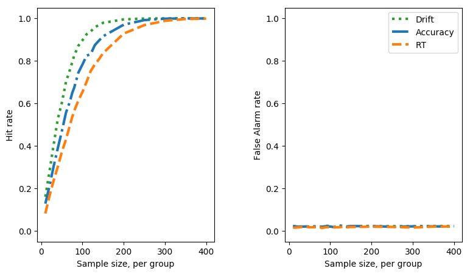

Simulated experiment sample size against hit rate and false alarm rate (for effect size of 2 vs 0, cohen’d d for drift parameter)

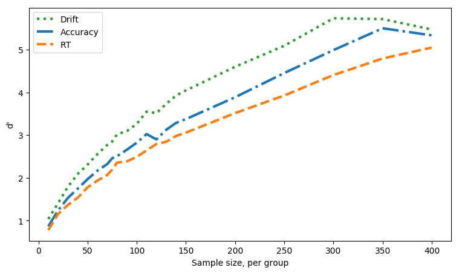

Simulated experiment sample size against d’ (for effect size of 2 vs 0 cohen’d d for drift parameter)

## With SATOs

The superiority of parameter recovery via a decision model becomes even more stark if there are systemmatic speed-accuracy trade-offs. To see this, we re-run the simulatations above, but with a shift in the boundary parameter before group A and group B, such that individuals from group B have a lower boundary, and so tend to make faster but less accurate decisions compared to group B. On top of this difference, we simulate different sizes of superiority of drift rate of group B over group A.

For the plots below, the drift rate difference is, as above, 0.1 (which, given the interindividual variability translates into an effect size of 2). The boundary parameter difference is also 0.1, a between group effect size 2.

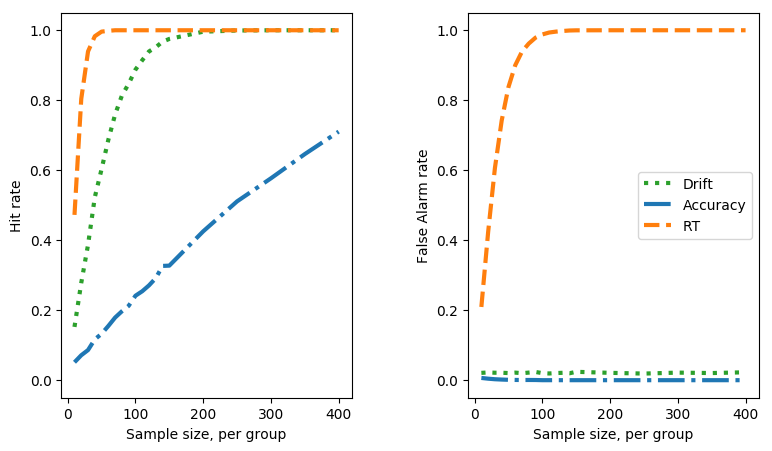

Simulated experiment sample size against hit rate and false alarm rate (for effect size of 2 vs 0, cohen’d d for drift parameter, and boundary parameter shifted 0.1 between groups)

When using the drift parameter as a measure the SATO between the groups does not induce false alarms. The accuracy measure is insensitive so also doesn’t suffer (but would if the boundary shift was in the opposite direction). The response time measure is catastrophically sensitive to false alarms, approaching 100% false alarm rate with larger samples.

Combining the hit rate and the false alarm rate to calculate d’, and so see measure sensitivity, Figure @ref(fig:SATOdprime).

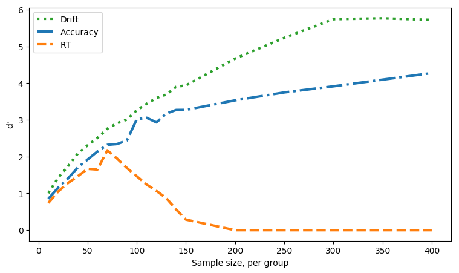

Simulated experiment sample size against d’ (effect size = 2 cohen’s d for drift parameter, 2 for boundary parameter)

# Discussion

## Qualifications

The results we showcase here and in the data explore hold only for the parameter regime choosen. We have not analytically proved that parameter recovery with the DDM will always provide a statistical power gain. We have chosen a simple experimental design, with a plausible trial numbers per participant and decision parameters which generate realistic values for speed and accuracy of responses, but it is possible that for smaller effects, at the boundaries of maximum or minimum speed or accuracy, and/or with higher within and between participant noise, that decision modelling may not have the benefits depicted here.

We have choose not to explore a within-participants design because the issue of systemmatically different speed-accuracy trade-offs between condtions seems, *prima facie*, less likely. For between groups designs we know of several prominent cases where systemmatic SATOs confounded conclusions. For example Pirrone et al. (2017) found that an apparent impairment of perceptual judgement among Autism Spectrum Disorder (ASD) participants could be attributed to a difference in their SATO. The ASD group responded more conservatively, but decision modelling showed their had equivalent senstivity to the non-ASD group. Ratcliff, Thapar, and McKoon (2006) found an analogous result for young vs old participants on perceptual discrimination and recognition memory tasks.

## Wider context

As well as power gains, and protection against SATO confounds, decision modelling has other benefits to offer the experimentalist. It allows differences between participants or groups to be localised to particular components of the decision process. Decision modelling, since it relies on the distribution of responses rather than just the means, can also reveal underlying differences when single variables (e.g. response time) are stable (White et al. 2010)

There is a growing awareness of the limitations of studying only speed or accuracy alone (Oppenheim 2017). A recent meta-analysis confirms a low correlation between speed and accuracy costs in psychological tasks (Hedge et al. in press). Vandierendonck (2017) compares seven model-free transformations which combine reaction time and accuracy, but finds none unambigiously superior either to the others or to inspecting raw reaction time and accuracy.

## Related work

A recent paper (Hedge, Powell, and Sumner 2018) used a comparable simulation based approach reached a similar conclusion to ours — that model-free transformations of reaction time and accuracy, even if hallowed by common usage, are outperformed by a model-based transformation which assumes a sequential sampling model like the DDM.

White, Servant, and Logan (2018) also present a parameter recovery account, but compare different variations of the sequential sampling models which are designed to account for decisions under conflict. Their focus is on comparing between different decision models rather than model-free and model-based transformations of reaction time and accuracy

Baker et al. (2019) using the simulation method to address a question of equal importance to experimentalist — how does the number of trials interact with sample size to affect statistical power. Like us they present an interactive demonstration of their findings https://shiny.york.ac.uk/powercontours/

## Getting started with decision modelling

For those who wish to apply decision models to their data have a range of tutorials available (A. Voss, Nagler, and Lerche 2013, Forstmann, Ratcliff, and Wagenmakers (2016)), as well as statistical computing packages which support model fitting (Wiecki, Sofer, and Frank 2013,A. Voss and Voss (2007))

# Acknowledgements

Jim Stone for discussion of the project and reading the manuscript. Feedback online and offline from the presentation of this work at the International meeting of the Psychonomics Society in Amsterdam, May 2018.

# References

Baker, Daniel H, Greta Vilidaite, Freya A Lygo, Anika K Smith, Tessa R Flack, Andre D Gouws, and Timothy J Andrews. 2019. “Power Contours: Optimising Sample Size and Precision in Experimental Psychology and Human Neuroscience.” *arXiv Preprint arXiv:1902.06122*.

Bezeau, Scott, and Roger Graves. 2001. “Statistical Power and Effect Sizes of Clinical Neuropsychology Research.” *Journal of Clinical and Experimental Neuropsychology* 23 (3). Taylor & Francis: 399–406.

Bogacz, Rafal, Eric Brown, Jeff Moehlis, Philip Holmes, and Jonathan D Cohen. 2006. “The Physics of Optimal Decision Making: A Formal Analysis of Models of Performance in Two-Alternative Forced-Choice Tasks.” *Psychological Review* 113 (4). American Psychological Association: 700–765.

Bruyer, Raymond, and Marc Brysbaert. 2011. “Combining Speed and Accuracy in Cognitive Psychology: Is the Inverse Efficiency Score (Ies) a Better Dependent Variable Than the Mean Reaction Time (Rt) and the Percentage of Errors (Pe)?” *Psychologica Belgica* 51 (1): 5–13.

Button, Katherine S, John PA Ioannidis, Claire Mokrysz, Brian A Nosek, Jonathan Flint, Emma SJ Robinson, and Marcus R Munafò. 2013. “Power Failure: Why Small Sample Size Undermines the Reliability of Neuroscience.” *Nature Reviews Neuroscience* 14 (5). Nature Publishing Group: 365–76.

Cohen, Jacob. 1962. “The Statistical Power of Abnormal-Social Psychological Research: A Review.” *The Journal of Abnormal and Social Psychology* 65 (3). American Psychological Association: 145–53.

Davidson, DJ, and Andrea E Martin. 2013. “Modeling Accuracy as a Function of Response Time with the Generalized Linear Mixed Effects Model.” *Acta Psychologica* 144 (1). Elsevier: 83–96.

Dutilh, Gilles, Jeffrey Annis, Scott D Brown, Peter Cassey, Nathan J Evans, Raoul PPP Grasman, Guy E Hawkins, et al. 2016. “The Quality of Response Time Data Inference: A Blinded, Collaborative Assessment of the Validity of Cognitive Models.” *Psychonomic Bulletin & Review*. Springer, 1–19.

Fitts, Paul M. 1966. “Cognitive Aspects of Information Processing: III. Set for Speed Versus Accuracy.” *Journal of Experimental Psychology* 71 (6). American Psychological Association: 849–57.

Forstmann, Birte U, Roger Ratcliff, and E-J Wagenmakers. 2016. “Sequential Sampling Models in Cognitive Neuroscience: Advantages, Applications, and Extensions.” *Annual Review of Psychology* 67. Annual Reviews: 641–66.

Geuter, Stephan, Guanghao Qi, Robert C Welsh, Tor D Wager, and Martin A Lindquist. 2018. “Effect Size and Power in fMRI Group Analysis.” *bioRxiv*. Cold Spring Harbor Laboratory, 295048.

Gold, Joshua I, and Michael N Shadlen. 2001. “Neural Computations That Underlie Decisions About Sensory Stimuli.” *Trends in Cognitive Sciences* 5 (1). Elsevier: 10–16.

———. 2002. “Banburismus and the Brain: Decoding the Relationship Between Sensory Stimuli, Decisions, and Reward.” *Neuron* 36 (2). Elsevier: 299–308.

Green, Swets J.A., D.M. 1966. *Signal Detection Theory and Psychophysics*. Wiley.

Hedge, Craig, Georgina Powell, and Petroc Sumner. 2018. “The Mapping Between Transformed Reaction Time Costs and Models of Processing in Aging and Cognition.” *Psychology and Aging* 33 (7). American Psychological Association: 1093.

Hedge, Craig, Georgina Powell, Aline Bompas, Solveiga Vivian-Griffiths, and Petroc Sumner. in press. “Low and Variable Correlation Between Reaction Time Costs and Accuracy Costs Explained by Accumulation Models: Meta-Analysis and Simulations.” *Psychological Bulletin*.

Heitz, Richard P. 2014. “The Speed-Accuracy Tradeoff: History, Physiology, Methodology, and Behavior.” *Frontiers in Neuroscience* 8. Frontiers: 150.

Ioannidis, John PA. 2005. “Why Most Published Research Findings Are False.” *PLoS Medicine* 2 (8). Public Library of Science: e124.

Jones, Matt, and Ehtibar N Dzhafarov. 2014. “Unfalsifiability and Mutual Translatability of Major Modeling Schemes for Choice Reaction Time.” *Psychological Review* 121 (1). American Psychological Association: 1–32.

Lerche, Veronika, and Andreas Voss. 2016. “Model Complexity in Diffusion Modeling: Benefits of Making the Model More Parsimonious.” *Frontiers in Psychology* 7. Frontiers: 1324.

Lovakov, Andrey, and Elena Agadullina. 2017. “Empirically Derived Guidelines for Interpreting Effect Size in Social Psychology.” PsyArXiv. doi:10.17605/OSF.IO/2EPC4.

Maxwell, Scott E. 2004. “The Persistence of Underpowered Studies in Psychological Research: Causes, Consequences, and Remedies.” *Psychological Methods* 9 (2). American Psychological Association: 147.

Open Science Collaboration. 2015. “Estimating the Reproducibility of Psychological Science.” *Science* 349 (6251). American Association for the Advancement of Science: aac4716.

Oppenheim, Gary M. 2017. “A Blind Spot in Correct Naming Latency Analyses.” *Cognitive Neuropsychology* 34 (1-2). Taylor & Francis: 33–41.

Palmer, John, Alexander C Huk, and Michael N Shadlen. 2005. “The Effect of Stimulus Strength on the Speed and Accuracy of a Perceptual Decision.” *Journal of Vision* 5 (5). The Association for Research in Vision; Ophthalmology: 1–1.

Park, Joonkoo, and Jeffrey J Starns. 2015. “The Approximate Number System Acuity Redefined: A Diffusion Model Approach.” *Frontiers in Psychology* 6. Frontiers: 1955.

Pashler, Harold, and Eric–Jan Wagenmakers. 2012. “Editors’ Introduction to the Special Section on Replicability in Psychological Science: A Crisis of Confidence?” *Perspectives on Psychological Science* 7 (6). Sage Publications Sage CA: Los Angeles, CA: 528–30.

Pirrone, Angelo, Habiba Azab, Benjamin Y Hayden, Tom Stafford, and James AR Marshall. 2018. “Evidence for the Speed–value Trade-Off: Human and Monkey Decision Making Is Magnitude Sensitive.” *Decision* 5 (2): 129–42.

Pirrone, Angelo, Abigail Dickinson, Rosanna Gomez, Tom Stafford, and Elizabeth Milne. 2017. “Understanding Perceptual Judgment in Autism Spectrum Disorder Using the Drift Diffusion Model.” *Neuropsychology* 31 (2). US: American Psychological Association: 173–80.

Pirrone, Angelo, Tom Stafford, and James AR Marshall. 2014. “When Natural Selection Should Optimize Speed-Accuracy Trade-Offs.” *Frontiers in Neuroscience* 8. Frontiers: 73.

Ratcliff, Roger. 1978. “A Theory of Memory Retrieval.” *Psychological Review* 85 (2). American Psychological Association: 59–108.

Ratcliff, Roger, and Russ Childers. 2015. “Individual Differences and Fitting Methods for the Two-Choice Diffusion Model of Decision Making.” *Decision* 2 (4). US: Educational Publishing Foundation: 237.

Ratcliff, Roger, and Gail McKoon. 2008. “The Diffusion Decision Model: Theory and Data for Two-Choice Decision Tasks.” *Neural Computation* 20 (4). MIT Press: 873–922.

Ratcliff, Roger, and Jeffrey N Rouder. 1998. “Modeling Response Times for Two-Choice Decisions.” *Psychological Science* 9 (5). SAGE Publications Sage CA: Los Angeles, CA: 347–56.

Ratcliff, Roger, Anjali Thapar, and Gail McKoon. 2006. “Aging and Individual Differences in Rapid Two-Choice Decisions.” *Psychonomic Bulletin & Review* 13 (4). Springer: 626–35.

Ravenzwaaij, Don van, Chris Donkin, and Joachim Vandekerckhove. 2017. “The Ez Diffusion Model Provides a Powerful Test of Simple Empirical Effects.” *Psychonomic Bulletin & Review* 24 (2). Springer: 547–56.

Sedlmeier, Peter, and Gerd Gigerenzer. 1989. “Do Studies of Statistical Power Have an Effect on the Power of Studies?” *Psychological Bulletin* 105 (2). American Psychological Association: 309–16.

Seli, Paul, Tanya R Jonker, James Allan Cheyne, and Daniel Smilek. 2013. “Enhancing Sart Validity by Statistically Controlling Speed-Accuracy Trade-Offs.” *Frontiers in Psychology* 4. Frontiers: 265.

Silberzahn, Raphael, Eric Luis Uhlmann, Dan Martin, Pasquale Anselmi, Frederik Aust, Eli C Awtrey, Štěpán Bahník, et al. 2017. “Many Analysts, One Dataset: Making Transparent How Variations in Analytical Choices Affect Results.” PsyArXiv.

Simmons, Joseph P, Leif D Nelson, and Uri Simonsohn. 2011. “False-Positive Psychology: Undisclosed Flexibility in Data Collection and Analysis Allows Presenting Anything as Significant.” *Psychological Science* 22 (11). Sage Publications Sage CA: Los Angeles, CA: 1359–66.

Smith, Philip L, and Roger Ratcliff. 2004. “Psychology and Neurobiology of Simple Decisions.” *Trends in Neurosciences* 27 (3). Elsevier: 161–68.

Stafford, Tom, Leanne Ingram, and Kevin N Gurney. 2011. “Piéron’s Law Holds During Stroop Conflict: Insights into the Architecture of Decision Making.” *Cognitive Science* 35 (8). Wiley Online Library: 1553–66.

Stanley, TD, Evan C Carter, and Hristos Doucouliagos. 2017. “What Meta-Analyses Reveal About the Replicability of Psychological Research.” Working paper, Deakin Laboratory for the Meta-Analysis of Research. http://www.deakin.edu.au/__data/assets/pdf_file/0007/1198456/WhatMeta-AnalysesReveal_WP.pdf.

Stone, James V. 2014. “Using Reaction Times and Binary Responses to Estimate Psychophysical Performance: An Information Theoretic Analysis.” *Frontiers in Neuroscience* 8. Frontiers: 35.

Szucs, Denes, and John PA Ioannidis. 2017. “Empirical Assessment of Published Effect Sizes and Power in the Recent Cognitive Neuroscience and Psychology Literature.” *PLoS Biology* 15 (3). Public Library of Science: e2000797.

Teodorescu, Andrei R, Rani Moran, and Marius Usher. 2016. “Absolutely Relative or Relatively Absolute: Violations of Value Invariance in Human Decision Making.” *Psychonomic Bulletin & Review* 23 (1). Springer: 22–38.

Townsend, James T, and F Gregory Ashby. 1983. *Stochastic Modeling of Elementary Psychological Processes*. CUP Archive.

Vandierendonck, André. 2017. “A Comparison of Methods to Combine Speed and Accuracy Measures of Performance: A Rejoinder on the Binning Procedure.” *Behavior Research Methods* 49 (2). Springer: 653–73.

Voss, Andreas, and Jochen Voss. 2007. “Fast-Dm: A Free Program for Efficient Diffusion Model Analysis.” *Behavior Research Methods* 39 (4). Springer: 767–75.

Voss, Andreas, Markus Nagler, and Veronika Lerche. 2013. “Diffusion Models in Experimental Psychology: A Practical Introduction.” *Experimental Psychology* 60 (6). Hogrefe Publishing: 385.

Wagenmakers, Eric-Jan, Han LJ Van Der Maas, and Raoul PPP Grasman. 2007. “An Ez-Diffusion Model for Response Time and Accuracy.” *Psychonomic Bulletin & Review* 14 (1). Springer: 3–22.

White, Corey N, Roger Ratcliff, Michael W Vasey, and Gail McKoon. 2010. “Using Diffusion Models to Understand Clinical Disorders.” *Journal of Mathematical Psychology* 54 (1). Elsevier: 39–52.

White, Corey N, Mathieu Servant, and Gordon D Logan. 2018. “Testing the Validity of Conflict Drift-Diffusion Models for Use in Estimating Cognitive Processes: A Parameter-Recovery Study.” *Psychonomic Bulletin & Review* 25 (1). Springer: 286–301.

Wickelgren, Wayne A. 1977. “Speed-Accuracy Tradeoff and Information Processing Dynamics.” *Acta Psychologica* 41 (1). Elsevier: 67–85.

Wiecki, Thomas V, Imri Sofer, and Michael J Frank. 2013. “HDDM: Hierarchical Bayesian Estimation of the Drift-Diffusion Model in Python.” *Frontiers in Neuroinformatics* 7. Frontiers: 14.

Yates, David, and Tom Stafford. 2018. “’Cognitive Strategy’ in Visual Search: How It Works and When It Generalises.” PsyArXiv. doi:10.17605/OSF.IO/5DUP8.

Zhang, Jiaxiang, and James B Rowe. 2014. “Dissociable Mechanisms of Speed-Accuracy Tradeoff During Visual Perceptual Learning Are Revealed by a Hierarchical Drift-Diffusion Model.” *Frontiers in Neuroscience* 8. Frontiers: 69.

[^1]: Note that we choose to cite work by the lead author here for illustration, rather than highlight any other researchers for their use of these suboptimal practices.
[^2]: Note, for high accuracy values t-tests may not be appropriate (they are strictly not applicable to proportions anyway, but this may become a real issue for values very close to 1 or 0).